# Proyecto Final

#### Metodos Analíticos 2023

> - Vianey Galindo Añel
> - Alberto Fuentes Chavarría

## Predicción inmediata para la venta de casas usando la paquetería BSTS de R y búsquedas de Google.

## Contexto

La predicción inmediata (nowcasting) es una écnica poderosa que permite estimar y predecir variables económicas y sociales en tiempo real, proporcionando información valiosa para la toma de decisiones rápidas y fundamentadas. Utilizar *nowcasting* permite contar con estimaciones tempranas de variables que generalmente se conocen con cierto desface o retraso considerable.

El *nowcasting* se vale de información de variables relacionadas con la variable objetivo y de las cuales si contamos con información de manera oportuna.

Esta tecnica tiene aplicaciones en diversos ámbitos como:

- Economía: Calculo PIB, inflación, desempleo.
- Fianzas: Precios de acciones, bonos, divisas.
- Salud: Propragación de enfermedades.
- Medio ambiente: Clima, calidad del aire,
- Retail: Demanda del consumidor.

Choi y Varian (2009, 2012) demostraron que los datos de búsqueda de Google podrían usarse como un señal externa para un modelo de predicción inmediata, pero sus métodos requerien seleccionar cuidadosamente el conjunto de predictores a utilizar.

## Objetivo

El objetivo del presentre trabajo es analizar el comportamiento de la serie temporal de datos con cifras de ventas de casas nuevas y ajustar un modelo bayesiano de series de tiempo (BSTS) para hacer predicciones inmediatas y selección de variables explicativas, el cual contemple los siguientes aspectos:

- Un módulo de series de tiempo, que capture la tendencia general y los patrones estacionales en los datos.
- Un componente de regresión que permita la incorporación de datos exógenos (e.g. datos de Google Trends).

## Metodología

### Obtención y pre-procesamiento de datos

[figure not shown]

Las cifras en esta base obtenida con la herramienta de Google están estandarizadas por lo que se estandariza la nuestra variable objetivo y se unen las dos bases de acuerdo a la fecha . El resultados es una sola base con 105 renglones (observaciones) y 71 columnas (fecha, ventas de casas y 69 covariables).

```r
data_housing <- read.csv("./data/HSN1FNSA_correlate.csv")
head(data_housing |> select(1:10))
```

```
##         Date HSN1FNSA X80.20.mortgage appreciation.rate home.appreciation
## 1 2004/01/01    0.942           1.080             0.380             1.198
## 2 2004/02/01    1.336           0.930             1.139             1.096
## 3 2004/03/01    1.973           2.091             1.734             1.520
## 4 2004/04/01    1.548           1.534             1.072             1.419
## 5 2004/05/01    1.730           1.595             1.524             1.584
## 6 2004/06/01    1.427           1.350             1.518             1.467
##   help.u.sell planned.community new.home.builder appreciation.rates city.land
## 1       0.724             1.682            1.371              1.173     0.987
## 2       0.813             1.770            1.460              1.119     1.472
## 3       1.523             1.653            1.894              1.356     1.535
## 4       1.603             1.341            1.619              1.152     1.509
## 5       1.502             1.877            1.648              1.181     1.902
## 6       1.385             1.603            1.529              1.304     1.748
```

## Serie de Tiempo

#### Visualización de los registros

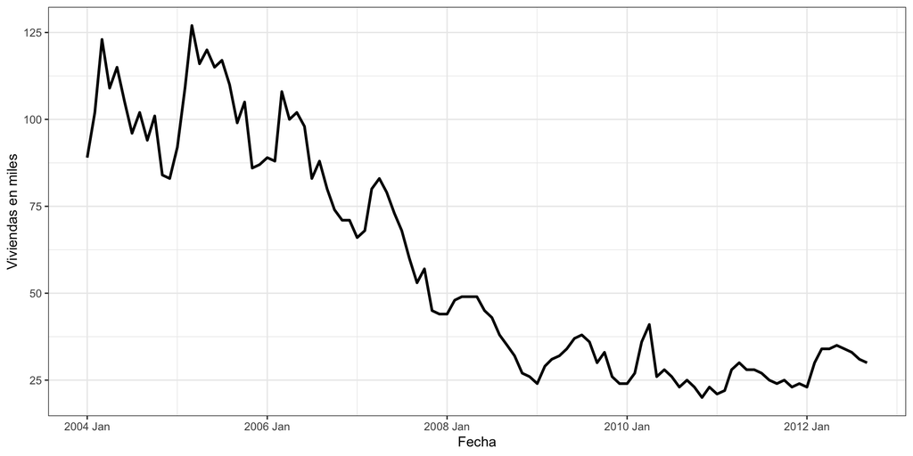

Gráficando las ventas de casas nuevas, observamos que alcanzaron su punto máximo en marzo de 2005.

- Su principal característica es la tendencia decreciente.
- Esta serie también tiene algo de estacionalidad mensual.

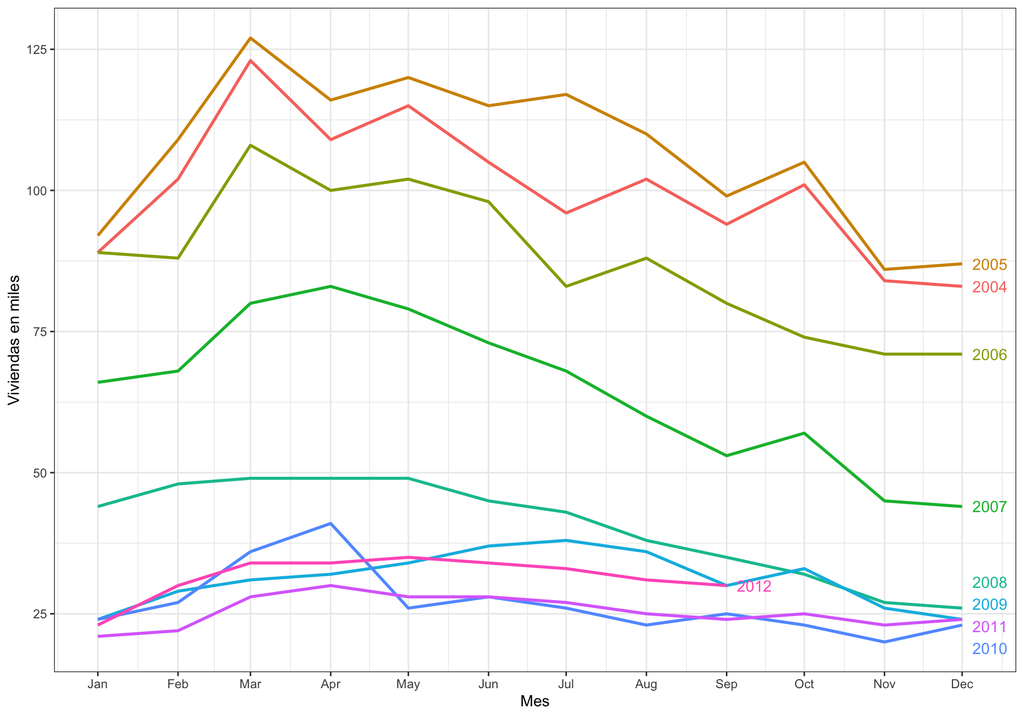

Podemos observar un patrón fuerte de estacionalidad en los primeros tres años. Con el mes de Marzo con un pico de ventas importante, una disminución el resto del año con un ligero repunte en el mes de Octubre. A partir de Abril 2007 se observa un comportamiento atípico relacionado a la crisis sufrida en el mercado americano. Para los años 2011 y 2012 podemos observar nuevamente una ligera estacionalidad mensual.

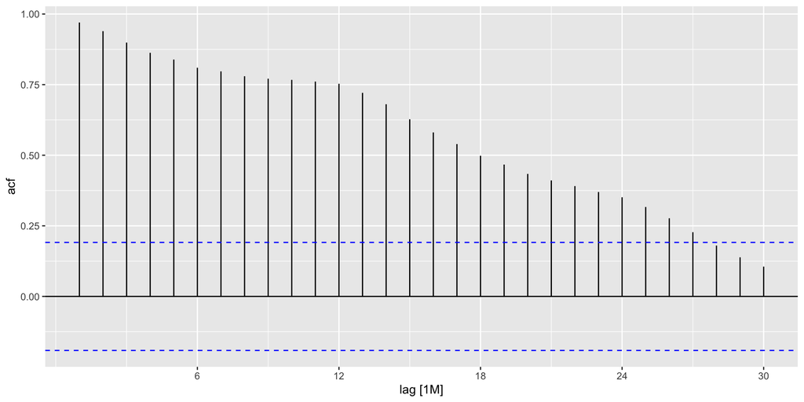

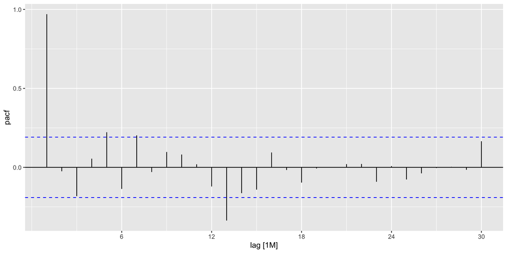